# Non-Linear Models

RD

March 26, 2020

## Initialization

```r
airbnb <- read.csv("C:/Users/edudi/Google Drive/ITESM/MCC-i/2nd Semester/Data Analytics/Final Project/Mexico City AirBnB Data/listings_1.csv",encoding = "UTG-8", stringsAsFactors = F, na.strings = c("NA"))
```

## Data Cleaning

**1. Eliminate unused features**

```r
att_to_eliminate <- c("id","listing_url","scrape_id","last_scraped","name","summary","space","description","experiences_offered","neighborhood_overview","notes","transit","access","interaction","house_rules","thumbnail_url","medium_url","picture_url","xl_picture_url","host_id","host_url","host_name","host_location","host_about","host_acceptance_rate","host_thumbnail_url","host_picture_url","host_neighbourhood","host_listings_count","host_verifications","street","neighbourhood","neighbourhood_group_cleansed","city","state","zipcode","market","smart_location","country_code","country","is_location_exact","square_feet","weekly_price","monthly_price","security_deposit","cleaning_fee","maximum_maximum_nights","minimum_minimum_nights","maximum_minimum_nights","minimum_maximum_nights","minimum_nights_avg_ntm","maximum_nights_avg_ntm","calendar_updated","availability_30","availability_60","availability_90","calendar_last_scraped","number_of_reviews_ltm","first_review","review_scores_accuracy","review_scores_cleanliness","review_scores_checkin","review_scores_communication","review_scores_location","review_scores_value","requires_license","license","jurisdiction_names","require_guest_profile_picture","require_guest_phone_verification","calculated_host_listings_count_entire_homes","calculated_host_listings_count_private_rooms","calculated_host_listings_count_shared_rooms","amenities","is_business_travel_ready","has_availability", "host_total_listings_count","host_since","last_review","property_type")
airbnb[att_to_eliminate] <- NULL
```

**2. Change from type strings to type factors features.**

```r
library(tidyverse)
att_to_factor <- c("host_response_time","neighbourhood_cleansed", "room_type","bed_type","cancellation_policy")
airbnb[att_to_factor] <- map(airbnb[att_to_factor], as.factor)
```

**3. Changing to double and integer type from string type features.**

```r
airbnb$reviews_per_month <- type.convert(airbnb$reviews_per_month, na.strings = "NA", dec = ".", numerals = "no.loss")
airbnb$host_response_rate <- type.convert(airbnb$host_response_rate, na.strings = "NA", dec = ".", numerals = "no.loss")
airbnb$price <- type.convert(airbnb$price, na.strings = "NA", dec = ".", numerals = "no.loss")
airbnb$bathrooms <- type.convert(airbnb$bathrooms, na.strings = "NA", dec = ".", numerals = "no.loss")
airbnb$bedrooms <- type.convert(airbnb$bedrooms, na.strings = "NA")
airbnb$beds <- type.convert(airbnb$beds, na.strings = "NA")
```

**4. Convert all true (t) and false (f) values to logical.**

```r
# Boolean types are replaced with a 0 or 1
airbnb$host_is_superhost[airbnb$host_is_superhost == "t"] <- 1
airbnb$host_is_superhost[airbnb$host_is_superhost == "f"] <- 0
airbnb$host_is_superhost <- type.convert(airbnb$host_is_superhost, na.strings = "NA")

airbnb$host_has_profile_pic[airbnb$host_has_profile_pic == "t"] <- 1
airbnb$host_has_profile_pic[airbnb$host_has_profile_pic == "f"] <- 0
airbnb$host_has_profile_pic <- type.convert(airbnb$host_has_profile_pic, na.strings = "NA")

airbnb$host_identity_verified[airbnb$host_identity_verified == "t"] <- 1
airbnb$host_identity_verified[airbnb$host_identity_verified == "f"] <- 0
airbnb$host_identity_verified <- type.convert(airbnb$host_identity_verified, na.strings = "NA")

airbnb$instant_bookable[airbnb$instant_bookable == "t"] <- 1
airbnb$instant_bookable[airbnb$instant_bookable == "f"] <- 0
airbnb$instant_bookable <- type.convert(airbnb$instant_bookable, na.strings = "NA")
```

**5. Identify and windsorize price feature, which is the feature of interest.**

```r
# $out function is to get the outliers of the boxplot
# airbnb_outliers <- boxplot(airbnb$price, plot = FALSE)$out
# To identify the rows where the outliers are located and removed them
# airbnb <- airbnb[-which(airbnb$price %in% airbnb_outliers),]

# Winsorize instead of elimination
# Price
price_bench <- quantile(x = airbnb$price, prob = 0.97)
airbnb$price[airbnb$price > price_bench] <- price_bench
price_bench_min <- quantile(x = airbnb$price, prob = 0.03)
airbnb$price[airbnb$price < price_bench_min] <- price_bench_min
# Accommodates
accommodates_bench <- quantile(x = airbnb$accommodates, prob = 0.98)
airbnb$accommodates[airbnb$accommodates > accommodates_bench] <- accommodates_bench
# Bathrooms
bath_bench <- quantile(x = airbnb$bathrooms, prob = 0.98, na.rm = TRUE)
airbnb$bathrooms[airbnb$bathrooms > bath_bench] <- bath_bench
# Bedrooms
bedroom_bench <- quantile(x = airbnb$bedrooms, prob = 0.98, na.rm = TRUE)
airbnb$bedrooms[airbnb$bedrooms > bedroom_bench] <- bedroom_bench
# Beds
bed_bench <- quantile(x = airbnb$beds, prob = 0.98, na.rm = TRUE)
airbnb$beds[airbnb$beds > bed_bench] <- bed_bench
# Guests_included
guests_bench <- quantile(x = airbnb$guests_included, prob = 0.97)
airbnb$guests_included[airbnb$guests_included > guests_bench] <- guests_bench
# Extra_people
extra_bench <- quantile(x = airbnb$extra_people, prob = 0.97)
airbnb$extra_people[airbnb$extra_people > extra_bench] <- extra_bench
# Minimum_nights
min_bench <- quantile(x = airbnb$minimum_nights, prob = 0.95)
airbnb$minimum_nights[airbnb$minimum_nights > min_bench] <- min_bench
# Maximum_nights was top to 365 days as we do not hold the information of how many days
max_bench <- 365
airbnb$maximum_nights[airbnb$maximum_nights > max_bench] <- max_bench
# Number_of_reviews
reviews_bench <- quantile(x = airbnb$number_of_reviews, prob = 0.95)
airbnb$number_of_reviews[airbnb$number_of_reviews > reviews_bench] <- reviews_bench
# Review Scores Rating
scores_bench <- quantile(x = airbnb$review_scores_rating, prob = 0.03, na.rm = TRUE)
airbnb$review_scores_rating[airbnb$review_scores_rating < scores_bench] <- scores_bench
# Calculated_host_listings_count
count_bench <- quantile(x = airbnb$calculated_host_listings_count, prob = 0.95)
airbnb$calculated_host_listings_count[airbnb$calculated_host_listings_count > count_bench] <- count_bench
# Reviews_per_month
month_bench <- quantile(x = airbnb$reviews_per_month, prob = 0.98, na.rm = TRUE)
airbnb$reviews_per_month[airbnb$reviews_per_month > month_bench] <- month_bench
```

**6. Replacing missing values with mean, mode, or median depending of the feature type and density behaviour.**

host_response_time = 3463(16.8%) categorical - use mode host_response_rate = 3463(16.8%) numerical - some extreme values so use median review_scores_rating = 4657(22.6%) numerical - some extreme values so use median reviews_per_month = 4401(21.4%) numerical - few extreme values can use mean.

less than 0.1% of missing values, but still present. can use mean for numerical values and mode for categorical values. host_is_superhost = 31 logical type use mode host_has_profile_pic = 31 logical type use mode host_identity_verified = 31 logical type use mode bathrooms = 7 use median bedrooms = 20 use median beds = 42 use median price = 8 use median

```r
# Create the function to obtain the mode
getmode <- function(v) {
   uniqv <- unique(v)
   uniqv[which.max(tabulate(match(v, uniqv)))]
}

airbnb$reviews_per_month[is.na(airbnb$reviews_per_month)] <- mean(airbnb$reviews_per_month, na.rm = TRUE)
airbnb$review_scores_rating[is.na(airbnb$review_scores_rating)] <- median(airbnb$review_scores_rating, na.rm = TRUE)
airbnb$host_response_rate[is.na(airbnb$host_response_rate)] <- median(airbnb$host_response_rate, na.rm = TRUE)

airbnb$host_total_listings_count[is.na(airbnb$host_total_listings_count)] <- median(airbnb$host_total_listings_count, na.rm = TRUE)
airbnb$bathrooms[is.na(airbnb$bathrooms)] <- median(airbnb$bathrooms, na.rm = TRUE)
airbnb$bedrooms[is.na(airbnb$bedrooms)] <- median(airbnb$bedrooms, na.rm = TRUE)
airbnb$beds[is.na(airbnb$beds)] <- median(airbnb$beds, na.rm = TRUE)

airbnb$host_response_time <- replace_na(data = airbnb$host_response_time, replace = getmode(airbnb$host_response_time))
airbnb$host_is_superhost <- replace_na(data = airbnb$host_is_superhost, replace = getmode(airbnb$host_is_superhost))
airbnb$host_has_profile_pic <- replace_na(data = airbnb$host_has_profile_pic, replace = getmode(airbnb$host_has_profile_pic))
airbnb$host_identity_verified <- replace_na(data = airbnb$host_identity_verified, replace = getmode(airbnb$host_identity_verified))

airbnb$price[is.na(airbnb$price)] <- median(airbnb$price, na.rm = TRUE)
```

**7. Normalize variables.**

```r
# Logarithmic transformation for price
airbnb$price <- log10(airbnb$price)
# The function to normalize data is (x - min(x))/(max(x) - min(x))
# We take only the numerical values to normalize
airbnb_norm <- as.data.frame(apply(airbnb[, c(2,7,8,10:13,15:22,25,26)], 2, function(x) (x - min(x))/(max(x)-min(x))))
airbnb[,c(2,7,8,10:13,15:22,25,26)] <- airbnb_norm
```

## Creating the models.

**Creating data partition to test and train the model.**

```r
library(caret)
training.samples <- airbnb$price %>% createDataPartition(p = 0.8, list = FALSE)
train <- airbnb[training.samples, ]
test <- airbnb[-training.samples, ]
```

**Multyple Polynomial Regression Model**

```r
# Multiple polynomial regression model with ONLY NUMERICAL.
degree <- 4
mprm <- lm(formula = price ~ poly(host_response_rate, degree,raw=TRUE) + poly(latitude, degree, raw = TRUE) + poly(longitude, degree, raw = TRUE) + poly(accommodates, degree, raw = TRUE) + poly(bathrooms, degree, raw = TRUE) + poly(bedrooms, degree, raw = TRUE) + poly(beds, degree, raw = TRUE) + poly(guests_included, degree, raw = TRUE) + poly(extra_people, degree,raw=TRUE) +poly(minimum_nights, degree,raw=TRUE) + poly(maximum_nights, degree,raw=TRUE) +poly(availability_365,degree,raw=TRUE) + poly(number_of_reviews,degree,raw=TRUE) + poly(review_scores_rating,degree,raw=TRUE) + poly(calculated_host_listings_count,degree,raw=TRUE) + poly(reviews_per_month,degree,raw=TRUE), data = train)
predicted_mprm <- mprm %>% predict(test)
data.frame(RMSE = RMSE(predicted_mprm, test$price), R2 = R2(predicted_mprm, test$price), AIC = AIC(mprm))
```

```
##        RMSE        R2       AIC
## 1 0.1726848 0.5420881 -10495.38
```

**Generalised additive models (GAMs)**

Downside: GAMs do not have an explicit form that can be nicely written down with algebra. Instead, they “smooth” over the data using kernels that determine the wiggliness the fitted model.

```r
library(mgcv)
# Remove property_type (Bug with too many variables)
#gam1 <- gam(price ~ s(host_response_rate) + s(latitude) + s(accommodates) + s(longitude) + s(bathrooms) + s(bedrooms) + s(beds) + s(guests_included) + s(extra_people) + s(availability_365) + s(number_of_reviews) +s(review_scores_rating) + s(reviews_per_month), data=train)
#predicted_gam1 <- gam1 %>% predict(test)
#data.frame(RMSE = RMSE(predicted_gam1, test$price), R2 = R2(predicted_gam1, test$price), AIC = AIC(gam1))
# gam.check(gam1)
```

**Logistic Regression with binary predictor**

1. First we create a new column with binary values. We assign a value of “TRUE” when the price of the listing is bigger than the mean of the population, and a value of “FALSE” when the price of the property is less than the mean of the population.

```r
# Create a copy of the airbnb daset without price variable
airbnb_blog <- airbnb
# Create a column with binary values
airbnb_blog$logistic_price <- ifelse(airbnb_blog$price > mean(airbnb_blog$price), 1, 0)
airbnb_blog <- airbnb_blog[, !names(airbnb) %in% c("price")]
```

3. Create model with cross validation (https://www.r-bloggers.com/evaluating-logistic-regression-models/)

When evaluating models, we often want to assess how well it performs in predicting the target variable on different subsets of the data. One such technique for doing this is k-fold cross-validation, which partitions the data into k equally sized segments (called ‘folds’). One fold is held out for validation while the other k-1 folds are used to train the model and then used to predict the target variable in our testing data. This process is repeated k times, with the performance of each model in predicting the hold-out set being tracked using a performance metric such as accuracy. The most common variation of cross validation is 10-fold cross-validation.

```r
library(caret)
# Define training control
train_control <- trainControl(method = "cv", number = 10)
training.samples <- airbnb_blog$logistic_price %>% createDataPartition(p = 0.8, list = FALSE)
train_blog <- airbnb_blog[training.samples, ]
test_blog <- airbnb_blog[-training.samples, ]
# Train the model on training set
blogm <- train(logistic_price ~ ., data = train_blog, trControl = train_control, method = "glm", family = binomial(link="logit"))
exp(coef(blogm$finalModel))
```

```
##                                    (Intercept)
##                                   3.793147e+01
##               `host_response_timewithin a day`
##                                   1.001697e+00
##         `host_response_timewithin a few hours`
##                                   9.228707e-01
##             `host_response_timewithin an hour`
##                                   1.065002e+00
##                             host_response_rate
##                                   5.803565e-01
##                              host_is_superhost
##                                   1.113574e+00
##                           host_has_profile_pic
##                                   3.409216e-01
##                         host_identity_verified
##                                   1.177966e+00
##             neighbourhood_cleansedAzcapotzalco
##                                   7.072221e-01
##            neighbourhood_cleansedBenito_Juarez
##                                   1.582537e+00
##                 neighbourhood_cleansedCoyoacan
##                                   2.177228e+00
##    neighbourhood_cleansedCuajimalpa_de_Morelos
##                                   6.729910e-01
##               neighbourhood_cleansedCuauhtemoc
##                                   3.865141e+00
##         neighbourhood_cleansedGustavo_A_Madero
##                                   1.058136e+00
##                neighbourhood_cleansedIztacalco
##                                   9.262273e-01
##               neighbourhood_cleansedIztapalapa
##                                   2.393388e+00
##   neighbourhood_cleansedLa_Magdalena_Contreras
##                                   6.417588e-01
##           neighbourhood_cleansedMiguel_Hidalgo
##                                   3.043068e+00
##               neighbourhood_cleansedMilpa_Alta
##                                   2.532854e+00
##                  neighbourhood_cleansedTlahuac
##                                   2.662009e+00
```

[output cut: 45 more lines]

```
##                                   3.074771e+00
##                               instant_bookable
##                                   9.331057e-01
##                    cancellation_policymoderate
##                                   8.208704e-01
## cancellation_policystrict_14_with_grace_period
##                                   9.914330e-01
##             cancellation_policysuper_strict_30
##                                   3.445397e+05
##             cancellation_policysuper_strict_60
##                                   2.712238e+05
##                 calculated_host_listings_count
##                                   1.979115e+00
##                              reviews_per_month
##                                   6.135716e-01
```

```r
summary(blogm)
```

```
##
## Call:
## NULL
##
## Deviance Residuals:
##     Min       1Q   Median       3Q      Max
## -3.4745  -0.6021  -0.1723   0.5877   3.3524
##
## Coefficients:
##                                                  Estimate Std. Error
## (Intercept)                                      3.635781   0.923858
## `host_response_timewithin a day`                 0.001696   0.238208
## `host_response_timewithin a few hours`          -0.080266   0.267145
## `host_response_timewithin an hour`               0.062977   0.271001
## host_response_rate                              -0.544113   0.279793
## host_is_superhost                                0.107574   0.052563
## host_has_profile_pic                            -1.076103   0.434705
## host_identity_verified                           0.163790   0.048686
## neighbourhood_cleansedAzcapotzalco              -0.346411   0.301441
## neighbourhood_cleansedBenito_Juarez              0.459029   0.135761
## neighbourhood_cleansedCoyoacan                   0.778053   0.149526
## neighbourhood_cleansedCuajimalpa_de_Morelos     -0.396023   0.195864
## neighbourhood_cleansedCuauhtemoc                 1.351998   0.159340
## neighbourhood_cleansedGustavo_A_Madero           0.056509   0.310558
## neighbourhood_cleansedIztacalco                 -0.076636   0.289715
## neighbourhood_cleansedIztapalapa                 0.872710   0.299861
## neighbourhood_cleansedLa_Magdalena_Contreras    -0.443543   0.279006
## neighbourhood_cleansedMiguel_Hidalgo             1.112866   0.160361
## neighbourhood_cleansedMilpa_Alta                 0.929347   0.990164
## neighbourhood_cleansedTlahuac                    0.979081   0.722257
## neighbourhood_cleansedTlalpan                   -0.504893   0.206793
## neighbourhood_cleansedVenustiano_Carranza        0.401164   0.265150
## neighbourhood_cleansedXochimilco                 0.875086   0.345063
## latitude                                         0.531972   0.611641
## longitude                                       -6.714075   0.500996
## `room_typeHotel room`                           -0.469885   0.137976
## `room_typePrivate room`                         -2.392771   0.053308
## `room_typeShared room`                          -3.339496   0.214612
## accommodates                                     3.648203   0.205984
## bathrooms                                        1.175291   0.164088
```

[output cut: 66 more lines]

```
## cancellation_policystrict_14_with_grace_period  -0.141 0.887970
## cancellation_policysuper_strict_30               0.078 0.937695
## cancellation_policysuper_strict_60               0.039 0.969251
## calculated_host_listings_count                   7.090 1.34e-12 ***
## reviews_per_month                               -3.890 0.000100 ***
## ---
## Signif. codes:  0 '***' 0.001 '**' 0.01 '*' 0.05 '.' 0.1 ' ' 1
##
## (Dispersion parameter for binomial family taken to be 1)
##
##     Null deviance: 22803  on 16456  degrees of freedom
## Residual deviance: 13432  on 16407  degrees of freedom
## AIC: 13532
##
## Number of Fisher Scoring iterations: 13
```

Evaluating the model:

1. Variable Importance: To assess the relative importance of individual predictors in the model, we can also look at the absolute value of the t-statistic for each model parameter. This technique is utilized by the varImp function in the caret package for general and generalized linear models.

```r
# Variable Importance
varImp(blogm)
```

```
## glm variable importance
##
##   only 20 most important variables shown (out of 49)
##
##                                      Overall
## `room_typePrivate room`              100.000
## accommodates                          39.448
## `room_typeShared room`                34.657
## longitude                             29.845
## review_scores_rating                  24.086
## neighbourhood_cleansedCuauhtemoc      18.891
## bathrooms                             15.944
## calculated_host_listings_count        15.783
## neighbourhood_cleansedMiguel_Hidalgo  15.447
## minimum_nights                        14.594
## beds                                  13.932
## number_of_reviews                     13.899
## availability_365                      13.153
## neighbourhood_cleansedCoyoacan        11.579
## extra_people                          11.288
## reviews_per_month                      8.652
## cancellation_policymoderate            8.190
## bedrooms                               7.954
## `room_typeHotel room`                  7.572
## neighbourhood_cleansedBenito_Juarez    7.518
```

```r
# Get model Accuracy and confusion Matrix
test_blog <- test_blog %>%
  mutate(prediction.logit = predict(blogm, test_blog),
         prediction.odds = exp(prediction.logit),
         prediction.probability = prediction.odds / (1+prediction.odds))
test_blog <- test_blog %>%
  mutate(prediction = case_when(prediction.probability<= median(test_blog$prediction.probability) ~ 0,
                                prediction.probability> median(test_blog$prediction.probability) ~ 1),
         prediction = factor(prediction, levels = c(0,1))) # make sure no gem is the first level of our factor
accuracy <- table(test_blog$prediction, test_blog$logistic_price)
sum(diag(accuracy))/sum(accuracy)
```

```
## [1] 0.8191541
```

```r
accuracy
```

```
##
##        0    1
##   0 1693  364
##   1  380 1677
```

```r
# Get model statistics as Rsquared, RMSE, MAE
blogm$results
```

```
##   parameter      RMSE  Rsquared       MAE      RMSESD RsquaredSD
## 1      none 0.3581445 0.4864763 0.2569428 0.006873916 0.01991385
##         MAESD
## 1 0.005597959
```

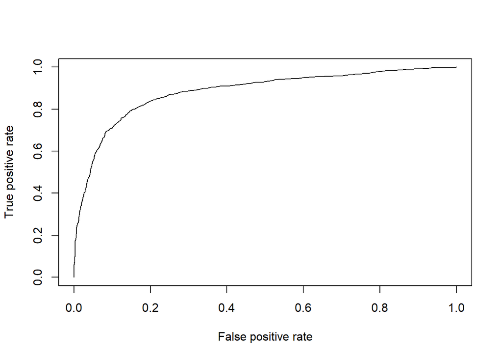

```r
# Get the ROC Curve computing the AUC
library(ROCR)
pred <- prediction(test_blog$prediction.logit, test_blog$logistic_price)
perf <- performance(pred, measure = "tpr", x.measure = "fpr")
plot(perf)
```

```r
auc <- performance(pred, measure = "auc")
auc <- auc@y.values[[1]]
auc
```

```
## [1] 0.8828856
```

The predictions are logits, i.e., logarithms of odds that the listings are more than the mean, but the observations simply tell us whether a listing price is more or not. For a meaningful comparison between predictions and observations, we need to transform the logits into a decision: listing price more than the mean or not. We can transform logits into odds by taking the exponential of the logit.

## Summary of models

**Simple Linear Model**

With the variable that has the most correlation: accommodates

```r
# Reloading the data partitions
training.samples <- airbnb$price %>% createDataPartition(p = 0.8, list = FALSE)
airbnb_train <- airbnb[training.samples, ]
airbnb_test <- airbnb[-training.samples, ]
# Simple Linear Regression model
simple_linear_regression_model <-lm(price ~ accommodates, data=train)
# Predict
predicted_simple_linear_regression_model <- simple_linear_regression_model %>% predict(test)
# Evaluate
data.frame(RMSE = RMSE(predicted_simple_linear_regression_model, test$price), R2 = R2(predicted_simple_linear_regression_model, test$price), AIC = AIC(simple_linear_regression_model))
```

```
##        RMSE        R2       AIC
## 1 0.2089645 0.3292866 -4176.863
```

```r
# Linear Test Assumptions
library(gvlma)
gvlma(simple_linear_regression_model) # NOT SATISFIED
```

```
##
## Call:
## lm(formula = price ~ accommodates, data = train)
##
## Coefficients:
##  (Intercept)  accommodates
##       0.2805        0.6305
##
##
## ASSESSMENT OF THE LINEAR MODEL ASSUMPTIONS
## USING THE GLOBAL TEST ON 4 DEGREES-OF-FREEDOM:
## Level of Significance =  0.05
##
## Call:
##  gvlma(x = simple_linear_regression_model)
##
##                       Value p-value                   Decision
## Global Stat        1280.713 0.00000 Assumptions NOT satisfied!
## Skewness            237.250 0.00000 Assumptions NOT satisfied!
## Kurtosis            306.238 0.00000 Assumptions NOT satisfied!
## Link Function       730.882 0.00000 Assumptions NOT satisfied!
## Heteroscedasticity    6.344 0.01178 Assumptions NOT satisfied!
```

**Multiple Linear Regression Model**

```r
# Using the same data partitions as simple linear regression model
# Multiple Linear Regression Model Construction
multiple_linear_regression_model <- lm(price ~ ., data=train)
# Predict
predicted_multiple_linear_regression_model <- multiple_linear_regression_model %>% predict(test)
# Evaluate
data.frame(RMSE = RMSE(predicted_multiple_linear_regression_model, test$price), R2 = R2(predicted_multiple_linear_regression_model, test$price), AIC = AIC(multiple_linear_regression_model))
```

```
##        RMSE        R2       AIC
## 1 0.1709087 0.5513629 -10997.81
```

```r
# Linear Test Assumptions for the model
gvlma(multiple_linear_regression_model) # NOT SATISFIED
```

```
##
## Call:
## lm(formula = price ~ ., data = train)
##
## Coefficients:
##                                    (Intercept)
##                                       0.668062
##                 host_response_timewithin a day
##                                      -0.036585
##           host_response_timewithin a few hours
##                                      -0.036965
##               host_response_timewithin an hour
##                                      -0.030729
##                             host_response_rate
##                                      -0.013002
##                              host_is_superhost
##                                       0.003493
##                           host_has_profile_pic
##                                      -0.044490
##                         host_identity_verified
##                                       0.001522
##             neighbourhood_cleansedAzcapotzalco
##                                       0.010421
##            neighbourhood_cleansedBenito_Juarez
##                                       0.032814
##                 neighbourhood_cleansedCoyoacan
##                                       0.040527
##    neighbourhood_cleansedCuajimalpa_de_Morelos
##                                      -0.029845
##               neighbourhood_cleansedCuauhtemoc
##                                       0.125755
##         neighbourhood_cleansedGustavo_A_Madero
##                                       0.050713
##                neighbourhood_cleansedIztacalco
##                                       0.035319
##               neighbourhood_cleansedIztapalapa
##                                       0.048834
##   neighbourhood_cleansedLa_Magdalena_Contreras
##                                      -0.049244
##           neighbourhood_cleansedMiguel_Hidalgo
```

[output cut: 65 more lines]

```
##
##
## ASSESSMENT OF THE LINEAR MODEL ASSUMPTIONS
## USING THE GLOBAL TEST ON 4 DEGREES-OF-FREEDOM:
## Level of Significance =  0.05
##
## Call:
##  gvlma(x = multiple_linear_regression_model)
##
##                       Value   p-value                   Decision
## Global Stat        5657.060 0.000e+00 Assumptions NOT satisfied!
## Skewness           1792.312 0.000e+00 Assumptions NOT satisfied!
## Kurtosis           3810.185 0.000e+00 Assumptions NOT satisfied!
## Link Function        51.055 8.982e-13 Assumptions NOT satisfied!
## Heteroscedasticity    3.508 6.107e-02    Assumptions acceptable.
```

```r
# splom(airbnb[c(11,7,8,9,10)])
summary(blogm)
```

```
##
## Call:
## NULL
##
## Deviance Residuals:
##     Min       1Q   Median       3Q      Max
## -3.4745  -0.6021  -0.1723   0.5877   3.3524
##
## Coefficients:
##                                                  Estimate Std. Error
## (Intercept)                                      3.635781   0.923858
## `host_response_timewithin a day`                 0.001696   0.238208
## `host_response_timewithin a few hours`          -0.080266   0.267145
## `host_response_timewithin an hour`               0.062977   0.271001
## host_response_rate                              -0.544113   0.279793
## host_is_superhost                                0.107574   0.052563
## host_has_profile_pic                            -1.076103   0.434705
## host_identity_verified                           0.163790   0.048686
## neighbourhood_cleansedAzcapotzalco              -0.346411   0.301441
## neighbourhood_cleansedBenito_Juarez              0.459029   0.135761
## neighbourhood_cleansedCoyoacan                   0.778053   0.149526
## neighbourhood_cleansedCuajimalpa_de_Morelos     -0.396023   0.195864
## neighbourhood_cleansedCuauhtemoc                 1.351998   0.159340
## neighbourhood_cleansedGustavo_A_Madero           0.056509   0.310558
## neighbourhood_cleansedIztacalco                 -0.076636   0.289715
## neighbourhood_cleansedIztapalapa                 0.872710   0.299861
## neighbourhood_cleansedLa_Magdalena_Contreras    -0.443543   0.279006
## neighbourhood_cleansedMiguel_Hidalgo             1.112866   0.160361
## neighbourhood_cleansedMilpa_Alta                 0.929347   0.990164
## neighbourhood_cleansedTlahuac                    0.979081   0.722257
## neighbourhood_cleansedTlalpan                   -0.504893   0.206793
## neighbourhood_cleansedVenustiano_Carranza        0.401164   0.265150
## neighbourhood_cleansedXochimilco                 0.875086   0.345063
## latitude                                         0.531972   0.611641
## longitude                                       -6.714075   0.500996
## `room_typeHotel room`                           -0.469885   0.137976
## `room_typePrivate room`                         -2.392771   0.053308
## `room_typeShared room`                          -3.339496   0.214612
## accommodates                                     3.648203   0.205984
## bathrooms                                        1.175291   0.164088
```

[output cut: 66 more lines]

```
## cancellation_policystrict_14_with_grace_period  -0.141 0.887970
## cancellation_policysuper_strict_30               0.078 0.937695
## cancellation_policysuper_strict_60               0.039 0.969251
## calculated_host_listings_count                   7.090 1.34e-12 ***
## reviews_per_month                               -3.890 0.000100 ***
## ---
## Signif. codes:  0 '***' 0.001 '**' 0.01 '*' 0.05 '.' 0.1 ' ' 1
##
## (Dispersion parameter for binomial family taken to be 1)
##
##     Null deviance: 22803  on 16456  degrees of freedom
## Residual deviance: 13432  on 16407  degrees of freedom
## AIC: 13532
##
## Number of Fisher Scoring iterations: 13
```

**Qunatile Regression Model**

```r
# Load the library for the cross validation quantile regression model
library(rqPen)
# Specify the value of x as a matrix of predictors
x_qrm <- data.matrix(airbnb[, names(airbnb) != "price"])
# Specify the values of y as the vector of response values
y_qrm <- airbnb$price
# Build the quantile model
qrm_q10 <- rq(train$price ~ ., data = train, tau = 0.10)
qrm_q25 <- rq(train$price ~ ., data = train, tau = 0.25)
qrm_q50 <- rq(train$price ~ ., data = train, tau = 0.50)
qrm_q75 <- rq(train$price ~ ., data = train, tau = 0.75)
qrm_q90 <- rq(train$price ~ ., data = train, tau = 0.90)
# Predict the results with test dataset
predicted_qrm10 <- qrm_q10 %>% predict(test)
predicted_qrm25 <- qrm_q25 %>% predict(test)
predicted_qrm50 <- qrm_q50 %>% predict(test)
predicted_qrm75 <- qrm_q75 %>% predict(test)
predicted_qrm90 <- qrm_q90 %>% predict(test)

# Get the RMSE
data.frame(RMSE10 = RMSE(predicted_qrm10, test$price), RMSE25 = RMSE(predicted_qrm25, test$price), RMSE50 = RMSE(predicted_qrm50, test$price), RMSE75 = RMSE(predicted_qrm75, test$price), RMSE90 = RMSE(predicted_qrm90, test$price))
```

```
##      RMSE10    RMSE25    RMSE50    RMSE75    RMSE90
## 1 0.2616261 0.2054132 0.1732415 0.1959846 0.2813022
```

```r
# Get the R2
data.frame(R2_10 = R2(predicted_qrm10, test$price),R2_25 = R2(predicted_qrm25, test$price),R2_50 = R2(predicted_qrm50, test$price),R2_75 = R2(predicted_qrm75, test$price),R2_90 = R2(predicted_qrm90, test$price))
```

```
##       R2_10     R2_25     R2_50     R2_75     R2_90
## 1 0.5199419 0.5416172 0.5483246 0.5431382 0.5099032
```

```r
# Get the AIC
data.frame(AIC_Q10=AIC(qrm_q10), AIC_Q25=AIC(qrm_q25), AIC_Q50=AIC(qrm_q50), AIC_Q75=AIC(qrm_q75), AIC_Q90=AIC(qrm_q90))
```

```
##     AIC_Q10   AIC_Q25   AIC_Q50   AIC_Q75  AIC_Q90
## 1 -8411.304 -12036.52 -12044.87 -7137.291 636.0356
```

**Ordinal Logistic Regression**

There are two types of logistic regression models we can apply to the dataset: Multinomial and Ordinal. Both of them are used when the dependent variable has more than two nominal categories. The only difference is the type of outcome, which can be nominal(i.e., no ordering to the categories) or ordinal (i.e., the categories have an order). In our case, we can just simple sort the prices to give order to the dataset and apply the ordinal logistic model.

https://www.theanalysisfactor.com/logistic-regression-models-for-multinomial-and-ordinal-variables/

First, we want the categories to be 0 or 1 creating a different column. So we create the one hot encoding dataframe from our variables with dummy variables

host_response_time (4 levels): within an hour(15482), within a few hours(2470), within a day(1747), a few days or more(872)

neighbourhood_cleansed (16 levels):

center_sector(16,504) = Cuauhtemoc (8140), Coyoacan(1770), Miguel_Hidalgo(3273), Benito_Juarez(3321),

south_sector(1200) = Milpa_Alta(16), Tlalpan(863), Xochimilco(142), Tlahuac(37), La_Magdalena_Contreras(142)

north_sector(2867) = Cuajimalpa_de_Morelos(431), Iztacalco (269), Azcapotzalco(247), Iztapalapa(267), Venustiano_Carranza(364), Alvaro_Obregon(952), Gustavo_A_Madero(337)

room_type (4 levels): Entire home/apt(10291), Hotel room(458), Private room(9455), Shared room(367).

bed_type (5 levels): Airbed(16), Couch(10), Futon Pull-out(57), Sofa(77), Real Bed(20411). Bed type does not hold sufficient evidence for non-real beds so we will remove this attribute

cancellation_policy: flexible(10223), moderate(6013), strict_14_with_grace_period(4302), super_strict_30(27), super_strict_60(6).

There are levels that can be grouped to reduce the number of columns after the one hot encoding. So, we will join the cancellation policy(3 levels) variable as flexible(10223), moderate(6013), strict(4335); host_response_time(3 levels) as within an hour(15482), within a few hours(2470), a_day_or_more(2619); the neighbourhood_cleansed(3 levels) variable as center_sector(16504), south_sector(1200), north_sector(2867); the room_type variable will be leaved as it is.

```r
library(plyr)
# Create a copy of the dataframe and sort the dataset by price
airbnb_log <- airbnb[order(airbnb$price), ]
# Identify categorical data and replace with proposed levels
airbnb_log$cancellation_policy <- revalue(airbnb_log$cancellation_policy, c("strict_14_with_grace_period"="strict","super_strict_30"="strict","super_strict_60"="strict"))
airbnb_log$host_response_time <- revalue(airbnb_log$host_response_time, c("within a day"="a_day_or_more","a few days or more"="a_day_or_more"))
airbnb_log$neighbourhood_cleansed <- revalue(airbnb_log$neighbourhood_cleansed, c("Cuauhtemoc"="center_sector","Coyoacan"="center_sector","Miguel_Hidalgo"="center_sector","Benito_Juarez"="center_sector", "Milpa_Alta"="south_sector","La_Magdalena_Contreras"="south_sector","Tlalpan"="south_sector","Xochimilco"="south_sector","Tlahuac"="south_sector", "Cuajimalpa_de_Morelos"="north_sector","Iztacalco"="north_sector","Azcapotzalco"="north_sector","Iztapalapa"="north_sector","Venustiano_Carranza"="north_sector","Alvaro_Obregon"="north_sector","Gustavo_A_Madero"="north_sector"))
# Eliminate unused variable
airbnb_log <- airbnb_log[, names(airbnb) != "bed_type"]
glimpse(airbnb_log)
```

```
## Observations: 20,571
## Variables: 25
## $ host_response_time             <fct> a_day_or_more, within an hour, ...
## $ host_response_rate             <dbl> 0.90, 1.00, 0.90, 0.90, 0.90, 0...
## $ host_is_superhost              <int> 1, 0, 1, 1, 0, 0, 0, 0, 0, 0, 0...
## $ host_has_profile_pic           <int> 1, 1, 1, 1, 1, 1, 1, 1, 1, 1, 1...
## $ host_identity_verified         <int> 1, 1, 1, 1, 0, 0, 1, 1, 0, 1, 0...
## $ neighbourhood_cleansed         <fct> center_sector, center_sector, c...
## $ latitude                       <dbl> 0.6929275, 0.7209255, 0.6986681...
## $ longitude                      <dbl> 0.4094291, 0.4913365, 0.4135393...
## $ room_type                      <fct> Private room, Private room, Sha...
## $ accommodates                   <dbl> 0.000, 0.000, 0.000, 0.000, 0.0...
## $ bathrooms                      <dbl> 0.2857143, 0.2857143, 0.2857143...
## $ bedrooms                       <dbl> 0.25, 0.25, 0.25, 0.25, 0.25, 0...
## $ beds                           <dbl> 0.1666667, 0.1666667, 0.1666667...
## $ price                          <dbl> 0, 0, 0, 0, 0, 0, 0, 0, 0, 0, 0...
## $ guests_included                <dbl> 0.00, 0.00, 0.00, 0.00, 0.00, 0...
## $ extra_people                   <dbl> 0.194, 0.200, 0.194, 0.000, 0.6...
## $ minimum_nights                 <dbl> 0.1666667, 1.0000000, 0.1666667...
## $ maximum_nights                 <dbl> 0.98626374, 0.24450549, 0.32692...
## $ availability_365               <dbl> 0.8575342, 0.9917808, 0.4767123...
## $ number_of_reviews              <dbl> 0.427184466, 0.213592233, 0.582...
## $ review_scores_rating           <dbl> 0.80, 0.95, 0.80, 0.50, 0.80, 0...
## $ instant_bookable               <int> 0, 0, 0, 0, 0, 0, 0, 1, 0, 0, 0...
## $ cancellation_policy            <fct> strict, moderate, strict, stric...
## $ calculated_host_listings_count <dbl> 0.20, 0.00, 0.20, 0.20, 0.05, 0...
## $ reviews_per_month              <dbl> 0.068669528, 0.058655222, 0.097...
```

After changing the name levels and grouping them, we can proceed to implement the one hot encoding for the factor variables.

```r
dmy <- dummyVars(" ~ .", data = airbnb_log)
airbnb_log <- data.frame(predict(dmy, newdata = airbnb_log))
glimpse(airbnb_log)
```

```
## Observations: 20,571
## Variables: 34
## $ host_response_time.a_day_or_more      <dbl> 1, 0, 1, 1, 0, 1, 0, 0, ...
## $ host_response_time.within.a.few.hours <dbl> 0, 0, 0, 0, 0, 0, 0, 0, ...
## $ host_response_time.within.an.hour     <dbl> 0, 1, 0, 0, 1, 0, 1, 1, ...
## $ host_response_rate                    <dbl> 0.90, 1.00, 0.90, 0.90, ...
## $ host_is_superhost                     <dbl> 1, 0, 1, 1, 0, 0, 0, 0, ...
## $ host_has_profile_pic                  <dbl> 1, 1, 1, 1, 1, 1, 1, 1, ...
## $ host_identity_verified                <dbl> 1, 1, 1, 1, 0, 0, 1, 1, ...
## $ neighbourhood_cleansed.north_sector   <dbl> 0, 0, 0, 0, 0, 0, 0, 1, ...
## $ neighbourhood_cleansed.center_sector  <dbl> 1, 1, 1, 1, 1, 1, 1, 0, ...
## $ neighbourhood_cleansed.south_sector   <dbl> 0, 0, 0, 0, 0, 0, 0, 0, ...
## $ latitude                              <dbl> 0.6929275, 0.7209255, 0....
## $ longitude                             <dbl> 0.4094291, 0.4913365, 0....
## $ room_type.Entire.home.apt             <dbl> 0, 0, 0, 0, 0, 1, 0, 0, ...
```

[output cut: 21 more lines]

```r
# Label the price data by the selected quantiles
airbnb_log$ordinal_price[airbnb_log$price <= quantile(x = airbnb_log$price, prob = 0.27)] <- "1 low"
airbnb_log$ordinal_price[airbnb_log$price > quantile(x = airbnb_log$price, prob = 0.27)] <- "2 medium"
#airbnb_log$ordinal_price[airbnb_log$price > quantile(x = airbnb_log$price, prob = 0.51)] <- "third_quantile"
airbnb_log$ordinal_price[airbnb_log$price > quantile(x = airbnb_log$price, prob = 0.75)] <- "3 high"
# Transform from character to factor
airbnb_log["ordinal_price"] <- map(airbnb_log["ordinal_price"], as.factor)
```

Now we can proceed to the creation of the model.

```r
# Divide train and test sets
training.samples <- airbnb_log$price %>% createDataPartition(p = 0.8, list = FALSE)
train_olog <- airbnb_log[training.samples, ]
test_olog <- airbnb_log[-training.samples, ]
# Eliminate price column from airbnb_log dataframe AS WELL as data that has perfect multicolinearity that impacts the model performance
train_olog <- train_olog[, !names(train_olog) %in% c("price","host_response_time.within.an.hour","neighbourhood_cleansed.south_sector","cancellation_policy.strict","room_type.Shared.room")]
#train_olog <- train_olog[, !names(train_olog) %in% c("price")]
test_olog <- test_olog[, !names(test_olog) %in% c("price")]
levels(train_olog$ordinal_price)
```

```
## [1] "1 low"    "2 medium" "3 high"
```

```r
# Build the model
library(MASS)
ord_logm= polr(ordinal_price ~ ., data = train_olog, Hess = TRUE)
summary(ord_logm)
```

```
## Call:
## polr(formula = ordinal_price ~ ., data = train_olog, Hess = TRUE)
##
## Coefficients:
##                                          Value Std. Error  t value
## host_response_time.a_day_or_more      -0.10822    0.07031  -1.5391
## host_response_time.within.a.few.hours -0.12509    0.05235  -2.3895
## host_response_rate                    -0.38692    0.11588  -3.3391
## host_is_superhost                      0.06398    0.03941   1.6236
## host_has_profile_pic                  -0.72197    0.34833  -2.0727
## host_identity_verified                 0.05338    0.03671   1.4540
## neighbourhood_cleansed.north_sector   -0.22271    0.10138  -2.1967
## neighbourhood_cleansed.center_sector   0.46735    0.09471   4.9347
## latitude                               1.89686    0.19227   9.8656
## longitude                             -5.61937    0.20288 -27.6987
## room_type.Entire.home.apt              3.21981    0.15728  20.4717
## room_type.Hotel.room                   3.22387    0.19209  16.7835
## room_type.Private.room                 1.18055    0.15309   7.7116
## accommodates                           3.44019    0.15834  21.7267
## bathrooms                              1.28784    0.12388  10.3960
## bedrooms                               0.95634    0.15530   6.1581
## beds                                  -1.27277    0.16216  -7.8490
## guests_included                        0.04103    0.08017   0.5118
## extra_people                           0.42778    0.06828   6.2650
## minimum_nights                        -0.54848    0.06850  -8.0072
## maximum_nights                         0.17508    0.03925   4.4604
## availability_365                       0.30035    0.04673   6.4269
## number_of_reviews                     -0.37883    0.07891  -4.8007
## review_scores_rating                   0.87439    0.07780  11.2391
## instant_bookable                      -0.12341    0.03483  -3.5434
## cancellation_policy.flexible          -0.15384    0.04633  -3.3205
## cancellation_policy.moderate          -0.22246    0.04735  -4.6978
## calculated_host_listings_count         0.71034    0.07035  10.0967
## reviews_per_month                     -0.50552    0.09458  -5.3447
##
## Intercepts:
##                 Value    Std. Error t value
## 1 low|2 medium    0.4139   0.4279     0.9674
## 2 medium|3 high   3.9323   0.4294     9.1570
##
## Residual Deviance: 24633.40
## AIC: 24695.40
```

https://www.r-bloggers.com/how-to-perform-ordinal-logistic-regression-in-r/

So, after the model is constructed, we proceed to evaluate it.

```r
# Creating model prediction class
predict_log_price <- predict(ord_logm, newdata=test_olog)
# Get model confusion Matrix
table(test_olog$ordinal_price, predict_log_price)
```

```
##           predict_log_price
##            1 low 2 medium 3 high
##   1 low      753      388      4
##   2 medium   357     1417    205
##   3 high      35      427    527
```

```r
data.frame(Accuracy = 1 - mean(as.character(test_olog$ordinal_price) != as.character(predict_log_price)))
```

```
##    Accuracy
## 1 0.6557257
```

```r
# Get model statistics as Rsquared, RMSE, AIC
nullmod <- polr(ordinal_price ~ 1, data = train_olog, Hess = TRUE)
data.frame(R2 = 1-logLik(ord_logm)/logLik(nullmod), RMSE = sqrt(sum(ord_logm$df.residual^2)/(4113-34)), AIC = AIC(ord_logm))
```

```
##          R2     RMSE     AIC
## 1 0.2877175 257.2062 24695.4
```

```r
# Get the ROC Curve computing the AUC
library(HandTill2001)
auc(multcap(
  response = train_olog$ordinal_price,
  predicted = as.matrix(predict(ord_logm, data=test_olog, type="probs"))))
```

```
## [1] 0.8305782
```

**Multinomial Logistic Regression**

```r
# Create a copy of the dataframe
airbnb_mlog <- airbnb
# Identify categorical data and replace with proposed levels
airbnb_mlog$cancellation_policy <- revalue(airbnb_mlog$cancellation_policy, c("strict_14_with_grace_period"="strict","super_strict_30"="strict","super_strict_60"="strict"))
airbnb_mlog$host_response_time <- revalue(airbnb_mlog$host_response_time, c("within a day"="a_day_or_more","a few days or more"="a_day_or_more"))
airbnb_mlog$neighbourhood_cleansed <- revalue(airbnb_mlog$neighbourhood_cleansed, c("Cuauhtemoc"="center_sector","Coyoacan"="center_sector","Miguel_Hidalgo"="center_sector","Benito_Juarez"="center_sector", "Milpa_Alta"="south_sector","La_Magdalena_Contreras"="south_sector","Tlalpan"="south_sector","Xochimilco"="south_sector","Tlahuac"="south_sector", "Cuajimalpa_de_Morelos"="north_sector","Iztacalco"="north_sector","Azcapotzalco"="north_sector","Iztapalapa"="north_sector","Venustiano_Carranza"="north_sector","Alvaro_Obregon"="north_sector","Gustavo_A_Madero"="north_sector"))
# Eliminate unused variable
airbnb_mlog <- airbnb_mlog[, names(airbnb_mlog) != "bed_type"]
#One hot Encoding
dmy <- dummyVars(" ~ .", data = airbnb_mlog)
airbnb_mlog <- data.frame(predict(dmy, newdata = airbnb_mlog))
# Label the price data by the selected quantiles
airbnb_mlog$ordinal_price[airbnb_mlog$price <= quantile(x = airbnb_log$price, prob = 0.27)] <- "1 Low"
airbnb_mlog$ordinal_price[airbnb_mlog$price > quantile(x = airbnb_log$price, prob = 0.27)] <- "2 Medium"
#airbnb_mlog$ordinal_price[airbnb_mlog$price > quantile(x = airbnb_log$price, prob = 0.51)] <- "third_quantile"
airbnb_mlog$ordinal_price[airbnb_mlog$price > quantile(x = airbnb_log$price, prob = 0.75)] <- "3 High"
# Transform from character to factor
airbnb_mlog["ordinal_price"] <- map(airbnb_mlog["ordinal_price"], as.factor)
# Divide train and test sets
training.samples <- airbnb_mlog$price %>% createDataPartition(p = 0.8, list = FALSE)
train_mlog <- airbnb_mlog[training.samples, ]
test_mlog <- airbnb_mlog[-training.samples, ]
# Eliminate price column from airbnb_log dataframe AS WELL as data that has perfect multicolinearity that impacts the model performance
#train_mlog <- train_mlog[, !names(train_mlog) %in% c("price","host_response_time.within.an.hour","neighbourhood_cleansed.south_sector","cancellation_policy.strict","room_type.Shared.room")]
train_mlog <- train_mlog[, !names(train_mlog) %in% c("price")]
test_mlog <- test_mlog[, !names(test_mlog) %in% c("price")]
# Build the model
library(nnet)
mul_logm= multinom(ordinal_price ~ ., data = train_mlog)
# Creating model prediction class
predict_mlog_price <- predict(mul_logm, newdata=test_mlog)
# Get model confusion Matrix
table(test_mlog$ordinal_price, predict_mlog_price)
```

```
##           predict_mlog_price
##            1 Low 2 Medium 3 High
##   1 Low      812      320     13
##   2 Medium   374     1380    225
##   3 High      42      433    514
```

```r
data.frame(Accuracy = 1-mean(as.character(test_mlog$ordinal_price) != as.character(predict_mlog_price)))
```

```
##    Accuracy
## 1 0.6579139
```

```r
# Get model statistics as Rsquared, RMSE, AIC
nullmod <- multinom(ordinal_price ~ 1, data = train_olog, Hess = TRUE)
data.frame(R2 = 1-logLik(mul_logm)/logLik(nullmod), RMSE = sqrt(sum(mul_logm$residuals^2)/(4113-34)), AIC = AIC(mul_logm))
```

```
##          R2     RMSE      AIC
## 1 0.3090321 1.335584 24016.27
```

```r
# Get the AUC
auc(multcap(
  response = train_mlog$ordinal_price,
  predicted = as.matrix(predict(mul_logm, data=test_mlog, type="probs"))))
```

```
## [1] 0.8420554
```